# Marketing Campaign

Lucas Andrade

2024-07-06

## Table of Contents

1. Business Context
2. Data Prep
3. Analysis
4. Conclusion

## Business Context

Our company, TechGadgets Inc., recently launched an experiment of two marketing campaigns to promote our latest product, the SmartGadget Pro. The experiment will focus on compare the effectiveness the campaigns in terms of brand awareness, drive traffic to our website, and ultimately boost sales.

How to measure:

1. **Brand awareness**
   - Reach
2. **Drive Traffic**
   - CTR
3. **Boost Sales**
   - Conversion Rate

## Data Prep

#### Libraries

```r
library(tidyverse)
library(janitor)
library(car)
library(magrittr)
```

#### Importing data

```r
# Previous Campaign (cc)
control_campaign <- read.csv('datasets/marketing_campaign/control_group.csv',
                    sep = ';')

control_campaign <- janitor::clean_names(control_campaign)

# Fill NAs
control_campaign <- control_campaign %>%
  tidyr::replace_na(list(
    x_of_impressions = as.integer(mean(control_campaign$x_of_impressions, na.rm = TRUE)),
    reach = as.integer(mean(control_campaign$reach, na.rm = TRUE)),
    x_of_website_clicks = as.integer(mean(control_campaign$x_of_website_clicks, na.rm = TRUE)),
    x_of_searches = as.integer(mean(control_campaign$x_of_website_clicks, na.rm = TRUE)),
    x_of_view_content = as.integer(mean(control_campaign$x_of_view_content, na.rm = TRUE)),
    x_of_add_to_cart = as.integer(mean(control_campaign$x_of_add_to_cart, na.rm = TRUE)),
    x_of_purchase = as.integer(mean(control_campaign$x_of_purchase, na.rm = TRUE))))


# New Campaign (nc)
test_campaign <- read.csv('datasets/marketing_campaign/test_group.csv',
                  sep = ';')
test_campaign <- janitor::clean_names(test_campaign)
```

#### Cleaning and transformation

```r
# Create CTR, Conversion Rate columns

control_campaign <- control_campaign %>%
  dplyr::mutate(
    ctr = (x_of_website_clicks / x_of_impressions)*100,
    conversion = (x_of_purchase / x_of_website_clicks)*100
  )

test_campaign <- test_campaign %>%
  dplyr::mutate(
    ctr = (x_of_website_clicks / x_of_impressions)*100,
    conversion = (x_of_purchase / x_of_website_clicks)*100
  )

# Merging datasets
campaigns <- dplyr::bind_rows(control_campaign, test_campaign)

# Fixing headers

campaigns <- campaigns %>%
  dplyr::rename(
    impressions = x_of_impressions,
    clicks = x_of_website_clicks,
    searches = x_of_searches,
    views = x_of_view_content,
    add_to_chart = x_of_add_to_cart,
    purchase = x_of_purchase
  )
```

#### Aggregating data

```r
agg_campaigns <- campaigns %>%
  dplyr::group_by(campaign_name) %>%
  dplyr::summarise_if(is.numeric,
               mean,
               na.rm = TRUE)
  #dplyr::mutate(across(where(is.double), as.integer))
```

## Analysis

### Overall Scenario

For an overall perspective, both campaigns had similar results in terms of searches, purchase and views. The Control Campaign has reached higher numbers of impressions, reach and clients who added products to a chart. The Test Campaign has beaten its rival in clicks and in money spend.

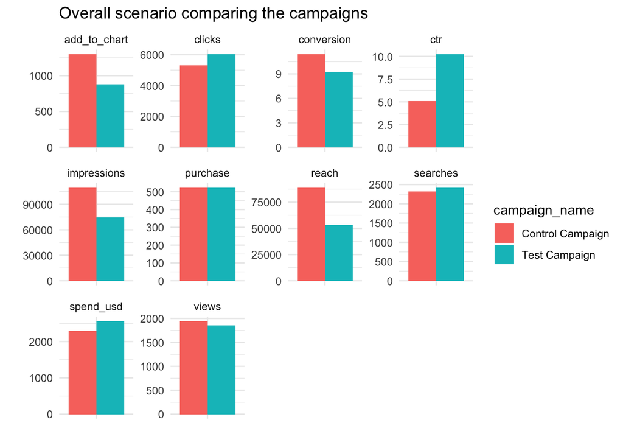

```r
longer_df <- agg_campaigns %>%
  tidyr::pivot_longer(cols = spend_usd:conversion,
                      names_to = 'metric',
                      values_to = 'mean')

longer_df %>%
  ggplot(aes(x = metric, y = mean, fill = campaign_name)) +
  geom_col(position = 'dodge') +
  facet_wrap(.~ metric, scales = 'free') +
  theme_minimal() +
  labs(x = '',
       y = '',
       title = 'Overall scenario comparing the campaigns') +
   theme(
     # Remove o título das facetas
    axis.text.x = element_blank(),   # Remove os textos do eixo X
    axis.ticks.x = element_blank()   # Remove os ticks do eixo X
  )
```

### Brand Awareness

Brand awareness refers to the extent to which consumers are familiar with a particular brand. It encompasses the recognition and recall of the brand by the target audience. High brand awareness means that consumers can easily identify the brand and associate it with specific products or services. This is crucial for building a strong brand presence and fostering customer loyalty.

#### Reach

- **Normality check**

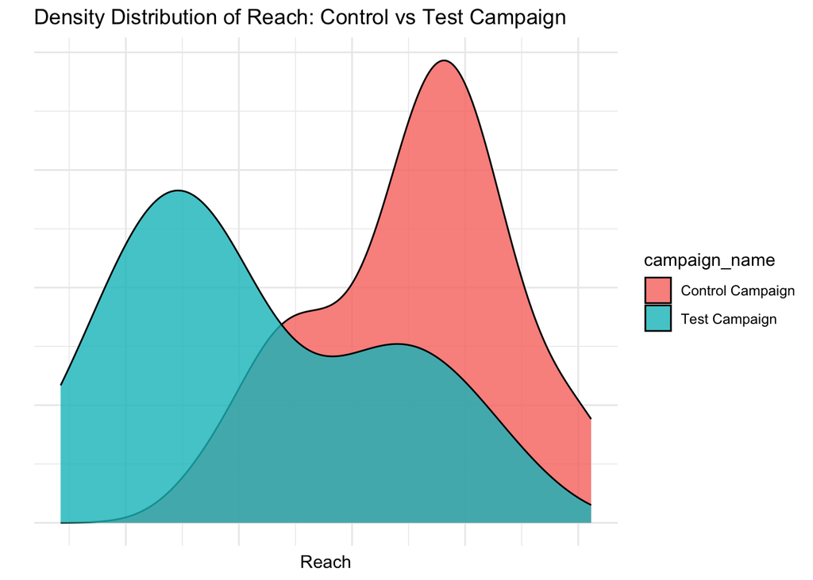

```r
campaigns %>%
  ggplot(aes(x = reach, fill = campaign_name))+
  geom_density(alpha = 0.8)+
  theme_minimal()+
  labs(title = "Density Distribution of Reach: Control vs Test Campaign",
       x = 'Reach',
       y = '')+
  theme(axis.text.x = element_blank(),
        axis.text.y = element_blank())
```

```r
shapiro.test(control_campaign$reach)
```

```
##
##  Shapiro-Wilk normality test
##
## data:  control_campaign$reach
## W = 0.97402, p-value = 0.6538
```

```r
shapiro.test(test_campaign$reach)
```

```
##
##  Shapiro-Wilk normality test
##
## data:  test_campaign$reach
## W = 0.93243, p-value = 0.057
```

Therefore the Shapiro test for the Test Campaign indicates a normality distribution, the p-value is just slightly above the parameter we use to define its normality. Using this information and the density curve, *I’ll consider the variable reach not normal distributed*

- **Variance check**

```r
leveneTest(reach ~ campaign_name,
           campaigns)
```

```
## Levene's Test for Homogeneity of Variance (center = median)
##       Df F value Pr(>F)
## group  1  2.5148 0.1182
##       58
```

The Levene test results indicates that the variance of variable reach in tow campaigns are homogeneous

As the normality was not confirmed and with homogeneous variance, I’ll use Mann-Whitney testing to compare the results of each campaign

- **Hipothesys**

Analyzing the distributions of the two samples in the density plots, along with the mean and median values of the reach of the two campaigns, there is a tendency to classify the control campaign as more successful than the test campaign.

We will perform a test to confirm this analysis, using the following hypotheses:

- H0: m_control = m_test
- H1: m_control > m_test
- **Testing**

```r
wilcox.test(control_campaign$reach,
            test_campaign$reach,
            paired = FALSE,
            alternative = c('greater'))
```

```
##
##  Wilcoxon rank sum exact test
##
## data:  control_campaign$reach and test_campaign$reach
## W = 743, p-value = 2.878e-06
## alternative hypothesis: true location shift is greater than 0
```

According to the test results, we can state with 95% confidence that the *reach of the control campaign is greater than the reach of the test campaign.*

### Drive Traffic

#### CTR (Click-Through Rate)

Measures the effectiveness of the campaign in generating traffic to the website. It is calculated as the percentage of people who clicked on the ad relative to the total number of people who saw the ad (impressions).

- **Normality check**

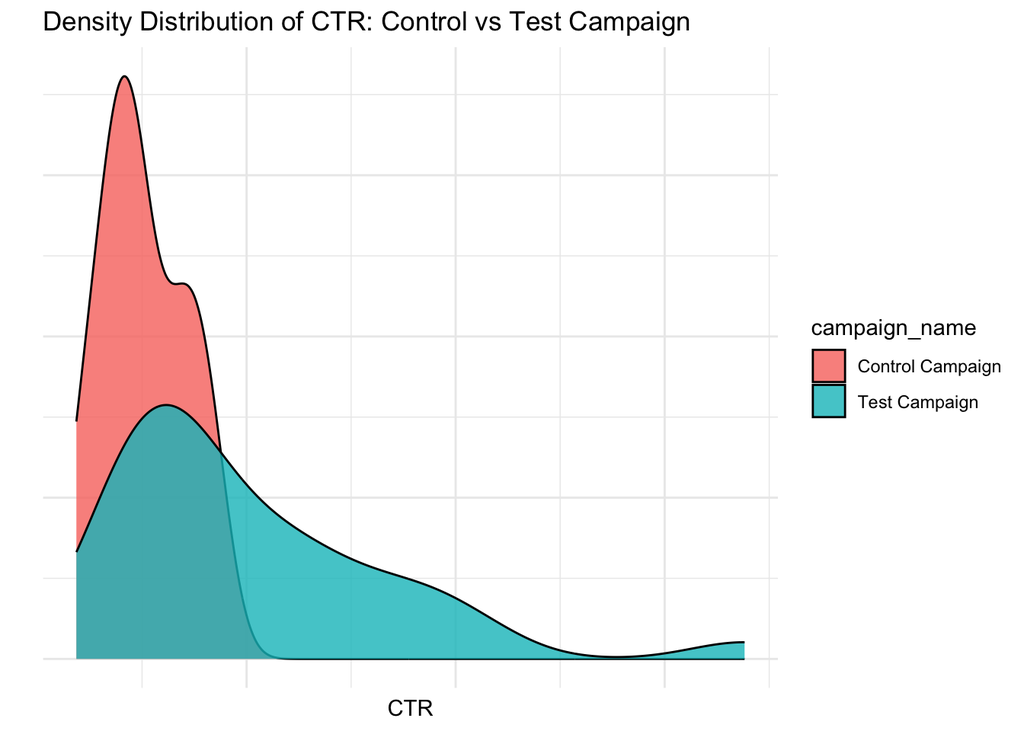

```r
campaigns %>%
  ggplot(aes(x = ctr, fill = campaign_name))+
  geom_density(alpha = 0.8)+
  theme_minimal()+
  labs(title = "Density Distribution of CTR: Control vs Test Campaign",
       x = 'CTR',
       y = '')+
  theme(axis.text.x = element_blank(),
        axis.text.y = element_blank())
```

```r
shapiro.test(control_campaign$ctr)
```

```
##
##  Shapiro-Wilk normality test
##
## data:  control_campaign$ctr
## W = 0.95833, p-value = 0.2807
```

```r
shapiro.test(test_campaign$ctr)
```

```
##
##  Shapiro-Wilk normality test
##
## data:  test_campaign$ctr
## W = 0.84092, p-value = 0.0004025
```

- **Variance check**

```r
leveneTest(campaigns$ctr, campaigns$campaign_name)
```

```
## Levene's Test for Homogeneity of Variance (center = median)
##       Df F value  Pr(>F)
## group  1  10.381 0.00209 **
##       58
## ---
## Signif. codes:  0 '***' 0.001 '**' 0.01 '*' 0.05 '.' 0.1 ' ' 1
```

Levene testing indicates the variances are not homogeneous

- **Hipóteses**

Analyzing the distributions of the two samples in the density plots, along with the mean and median values of the CTR of the two campaigns, there is a tendency to classify the test campaign as more successful than the control campaign.

We will perform a test to confirm this analysis, using the following hypotheses:

- H0: m_control = m_test
- H1: m_control < m_test
- **Testing**

```r
wilcox.test(control_campaign$ctr, test_campaign$ctr,
            alternative = 'less',
            var.equal = FALSE,
            paired = FALSE)
```

```
##
##  Wilcoxon rank sum exact test
##
## data:  control_campaign$ctr and test_campaign$ctr
## W = 199, p-value = 6.698e-05
## alternative hypothesis: true location shift is less than 0
```

According to the test results, we can state with 95% confidence that the **Test Campaigns is more successful than n the Control Campaign in terms of CTR**

### Boost Sales

#### Conversion Rate

The conversion rate is a key performance metric used to assess the effectiveness of a marketing campaign. It measures the percentage of users who take a desired action out of the total number of users who interacted with the campaign.

- **Normality Check**

[figure not shown]

```r
campaigns %>%
ggplot(aes(x= conversion, fill = campaign_name)) +
  geom_density(alpha = 0.8)+
  labs(title = "Density Distribution of Conversion Rate: Control vs Test Campaign",
       x = 'Reach',
       y = '')+
  theme(axis.text.x = element_blank(),
        axis.text.y = element_blank())
```

```r
shapiro.test(control_campaign$conversion)
```

```
##
##  Shapiro-Wilk normality test
##
## data:  control_campaign$conversion
## W = 0.89297, p-value = 0.005677
```

```r
shapiro.test(test_campaign$conversion)
```

```
##
##  Shapiro-Wilk normality test
##
## data:  test_campaign$conversion
## W = 0.92547, p-value = 0.03727
```

- **Variance check**

```r
leveneTest(campaigns$conversion, campaigns$campaign_name)
```

```
## Levene's Test for Homogeneity of Variance (center = median)
##       Df F value  Pr(>F)
## group  1  2.8671 0.09577 .
##       58
## ---
## Signif. codes:  0 '***' 0.001 '**' 0.01 '*' 0.05 '.' 0.1 ' ' 1
```

- **Hypothesis**

Analyzing the distributions of the two samples in the density plots, along with the mean and median values of the Conversion rate of the two campaigns, there is a tendency to classify the control campaign as more successful than the test campaign.

We will perform a test to confirm this analysis, using the following hypotheses:

- H0: m_control = m_test
- H1: m_control > m_test
- **Testing**

```r
wilcox.test(control_campaign$conversion,
            test_campaign$conversion,
            paired = FALSE,
            alternative = 'greater')
```

```
##
##  Wilcoxon rank sum exact test
##
## data:  control_campaign$conversion and test_campaign$conversion
## W = 523, p-value = 0.143
## alternative hypothesis: true location shift is greater than 0
```

## Conclusion

Considering the significant difference in CTR levels between the two campaigns, a more in-depth analysis focused on this topic is recommended. CTR is considered the KPI that best reflects the efficiency of a campaign in generating leads and traffic.